# Sampling Exercises

January 2020

**Exercise 1 (Optional)**

This exercise is for those wishing to understand stratified allocation a bit better. It is to be calculated by hand (or using R, a spreadsheet or a calculator). Note: You might have to round up or down. Consider this (very small) population:

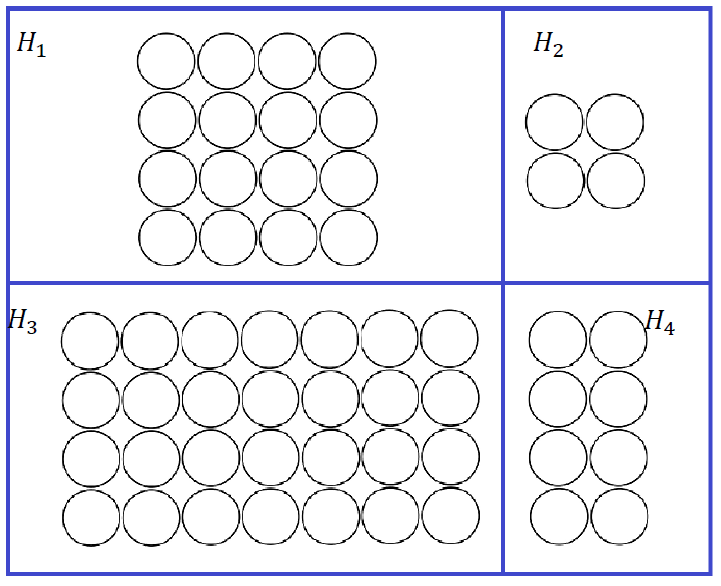

- Let \(n = 24\)
1. Proportionally allocate a sample of size \(n\). Recall that for proportional allocation, \(n_h = n \cdot\frac{N_h}{\sum_{h = 1}^H N_h}\).
2. Given the standard errors \(s_1 = 1, s_2 = 8, s_3 = 3, s_4 = 9\) for some variable of interest, optimally allocate a sample of size \(n\). Recall that for optimal (Neyman) allocation, \(n_h = n \cdot \frac{N_h s_h}{\sum_{h = 1}^H N_h s_h}\)

**Solution to exercise 1**

By counting, we get that \(N = 56\), \(N_1 = 16\), \(N_2 = 4\), \(N_3 = 28\) and \(N_4 = 8\), thus \(\sum_{h = 1}^4 N_h = N = 56\)

1. For the proportional allocation, we get
- \(n_1 = 24 \cdot \frac{16}{56} \sim 7\)
- \(n_2 = 24 \cdot \frac{4}{56} \sim 2\)
- \(n_3 = 24 \cdot \frac{28}{56} \sim 12\)
- \(n_4 = 24 \cdot \frac{8}{56} \sim 3\)
1. For the optimal allocation, we get that

\(\sum_{h = 1}^4 N_h s_h = 16 \cdot 1 + 4 \cdot 8 + 28 \cdot 3 + 8 \cdot 9= 204\)

- \(n_1 = 24 \cdot \frac{16 \cdot 1}{204} \sim 2\)
- \(n_2 = 24 \cdot \frac{4 \cdot 8}{204} \sim 4\)
- \(n_3 = 24 \cdot \frac{28 \cdot 3}{204} \sim 10\)
- \(n_4 = 24 \cdot \frac{8 \cdot 9}{204} \sim 8\)

## Exercise 2

- Using the data frame **mydata_estimation.Rda**,
1. Stratify by region and sector as in the presentation
2. Proprotionally allocate a sample of size \(n = 2000\)
3. Save your sample for later use

**Solution to exercise 2**

First stratification:

```r
load(file = "mydata_estimation.Rda")

Strata <- unique (mydata_estimation[,c("sector", "region")])
Strata <- Strata[order(Strata$sector, Strata$region),]
rownames(Strata) <- NULL
Strata$stratum <- 1:dim(Strata)[1]
Strata <- Strata[c(3,1,2)]

mydata_estimation <- merge (mydata_estimation, Strata,
                          by=c("sector", "region"))
```

Then merging stratum counts onto the Strata data frame:

```r
Nh <- aggregate (mydata_estimation$stratum,
                 list(stratum=mydata_estimation$stratum),
                 length)
names(Nh)[2] <- "Nh"

Strata <- merge(Strata, Nh, by="stratum")
```

Load samplingbook:

```r
library(samplingbook)
```

Then allocate the sample

```r
n <- 2000
alloc1 <- stratasamp (n, Nh=Strata$Nh)

Strata$nh <- alloc1[2,]
```

And finally draw and save the sample:

```r
library (sampling)
mydata_estimation <- mydata_estimation[order(mydata_estimation$stratum),]

samprop <- sampling::strata (mydata_estimation,
                       stratanames="stratum",
                       size=Strata$nh,
                       method="srswor")

mysampprop <- getdata (mydata_estimation, samprop)

save (mysampprop, file="mysampprop.Rda")
```

## Exercise 3

- Using the data frame **mydata_estimation.Rda**
1. Stratify by sector and number of employees \(E\) in 3 size groups:

   \(E \leq 100\), \(100 < E \leq 500\), \(500 < E\)
2. Optimally allocate a sample of size \(n = 2500\) with the interest variable turnover_2019
3. Correct your allocation if needed
4. Save your sample for later use

**Solution to exercise 3**

First stratification:

```r
load(file = "mydata_estimation.Rda")

mydata_estimation$size <- cut(mydata_estimation$Nr_empl_reg,
                            c(0, 100, 500, 1e7),
                            right = TRUE,
                            include.lowest = FALSE,
                            labels = c("0-100", "101-500", "501+"))

Strata <- unique (mydata_estimation[,c("sector", "size")])
Strata <- Strata[order(Strata$sector, Strata$size),]
rownames(Strata) <- NULL
Strata$stratum <- 1:dim(Strata)[1]
Strata <- Strata[c(3,1,2)]

mydata_estimation <- merge (mydata_estimation, Strata,
                          by=c("sector", "size"))
```

Then merging stratum counts onto the Strata data frame:

```r
Nh <- aggregate (mydata_estimation$stratum,
                 list(stratum=mydata_estimation$stratum),
                 length)
names(Nh)[2] <- "Nh"

sh <- aggregate (mydata_estimation$turnover_2019,
                 list(stratum=mydata_estimation$stratum),
                 sd, na.rm=TRUE)
names(sh)[2] <- "sh"

Strata <- merge(Strata, Nh, by="stratum")
Strata <- merge(Strata, sh, by="stratum")
```

Load samplingbook:

```r
library(samplingbook)
```

Then allocate the sample

```r
n <- 2500
alloc2 <- stratasamp (n, Nh=Strata$Nh, Sh=Strata$sh, type="opt")

Strata$nh <- alloc2[2,]
```

Check allocation:

```r
impossible_allocation <- (Strata$nh > Strata$Nh)
sum(impossible_allocation)
```

```
## [1] 0
```

There are no too big allocations.

And finally draw and save the sample:

```r
library (sampling)
mydata_estimation <- mydata_estimation[order(mydata_estimation$stratum),]

samopt <- sampling::strata (mydata_estimation,
                       stratanames="stratum",
                       size=Strata$nh,
                       method="srswor")

mysampopt <- getdata (mydata_estimation, samopt)

save (mysampopt, file="mysamopt.Rda")
```

## Exercise 4

- Using the data frame **mydata_estimation.Rda**
1. Stratify by sector and region
2. Weighted proportionally allocate a sample of size \(n = 3000\) by \(\frac{1}{3} \cdot\) number of employees \(+ \frac{2}{3} \cdot\) turnover (i.e. you need two proportional allocations and then add them using the weights \(\frac{1}{3}\) and \(\frac{2}{3}\))
3. Correct your allocation if needed
4. Save your sample for later use

**Solution to exercise 4**

First stratification:

```r
load(file = "mydata_estimation.Rda")

Strata <- unique (mydata_estimation[,c("sector", "region")])
Strata <- Strata[order(Strata$sector, Strata$region),]
rownames(Strata) <- NULL
Strata$stratum <- 1:dim(Strata)[1]
Strata <- Strata[c(3,1,2)]

mydata_estimation <- merge (mydata_estimation, Strata,
                          by=c("sector", "region"))
```

Then merging stratum counts onto the Strata data frame:

```r
Nh <- aggregate (mydata_estimation$stratum,
                 list(stratum=mydata_estimation$stratum),
                 length)
names(Nh)[2] <- "Nh"

Nempl <- aggregate (mydata_estimation$Nr_empl_reg,
                 list(stratum=mydata_estimation$stratum),
                 sum, na.rm=TRUE)
names(Nempl)[2] <- "n_empl"

To <- aggregate (mydata_estimation$turnover_2019,
                 list(stratum=mydata_estimation$stratum),
                 sum, na.rm=TRUE)
names(To)[2] <- "T.O."

Strata <- merge(Strata, Nh, by="stratum")
Strata <- merge(Strata, Nempl, by="stratum")
Strata <- merge(Strata, To, by="stratum")
```

Load samplingbook:

```r
library(samplingbook)
```

Then allocate the sample

```r
n <- 3000
alloc1 <- stratasamp (n, Nh=Strata$n_empl)
alloc2 <- stratasamp (n, Nh=Strata$T.O.)

Strata$emplh <- alloc1[2,]
Strata$toh <- alloc2[2,]

Strata$nh <- round(1/3*Strata$emplh + 2/3*Strata$toh)
```

Check allocation:

```r
impossible_allocation <- (Strata$nh > Strata$Nh)
sum(impossible_allocation)
```

```
## [1] 0
```

There are no too big allocations.

And finally draw and save the sample:

```r
library (sampling)
mydata_estimation <- mydata_estimation[order(mydata_estimation$stratum),]

samweigh <- sampling::strata (mydata_estimation,
                       stratanames="stratum",
                       size=Strata$nh,
                       method="srswor")

mysampweigh <- getdata (mydata_estimation, samweigh)

save (mysampweigh, file="mysampweigh.Rda")
```